# R Zone 4: Chapter 12 and 15

Brandon Hufstetler, Garrett Alarcon, Jinan Andrews, Anson Cheng, Nick Forrest, and Nestor Herandez

5 August 2019

# Chapter 12

### READ IN AND PREPARE THE DATA

```r
  setwd("~/IMGT680")
  adult <- read.csv(file = "adult.txt", stringsAsFactors=TRUE)

  # Collapse categories as in Chapter 11
  # We will work with a small sample of data
  adult <- adult[1:500,]
```

### DETERMINE HOW MANY INDICATOR VARIABLES ARE NEEDED

#### Here we are looking at how many different unique levels(categories) are present within each feature in the data. This shows that there are 2 different levels of income, 2 different levels of gender, 5 different levels of race, 9 different levels of workclass, and 7 different levels of marital status in the adult.txt dataset.

```r
  unique(adult$income)             # One variable for income
```

```
## [1] <=50K. >50K.
## Levels: <=50K. >50K.
```

```r
  unique(adult$sex)                   # One variable for sex
```

```
## [1] Male   Female
## Levels: Female Male
```

```r
  unique(adult$race)                  # Four variables for race
```

```
## [1] White              Black              Asian-Pac-Islander
## [4] Amer-Indian-Eskimo Other
## Levels: Amer-Indian-Eskimo Asian-Pac-Islander Black Other White
```

```r
  unique(adult$workclass)         # Three variables for workclass
```

```
## [1] State-gov        Self-emp-not-inc Private          Federal-gov
## [5] Local-gov        ?                Self-emp-inc
## 9 Levels: ? Federal-gov Local-gov Never-worked Private ... Without-pay
```

```r
  unique(adult$marital.status)   # Four variables for marital.status
```

```
## [1] Never-married         Married-civ-spouse    Divorced
## [4] Married-spouse-absent Separated             Married-AF-spouse
## [7] Widowed
## 7 Levels: Divorced Married-AF-spouse ... Widowed
```

### CREATE INDICATOR VARIABLES

#### First, we define the new indicator variables that we want to populate. These will all be binary indicators, so if a specific level is present in the data, the value of the indicator is equal to 1. The levels in this data are mutually exclusive, so only one level from each feature can occur in one observation. Therefore, it is not necessary to make an indicator variable for every level contained in a feature. The level that is left out is the assume baseline, as it is the only other option given the other indicator variables from that feature are 0.

```r
  adult$race_white <- adult$race_black <- adult$race_as.pac.is <-
  adult$race_am.in.esk <- adult$wc_gov <-  adult$wc_self <- adult$wc_priv <-
  adult$ms_marr <- adult$ms_div <- adult$ms_sep <- adult$ms_wid <-
  adult$income_g50K <- adult$sex2 <- c(rep(0, length(adult$income)))
  for (i in 1:length(adult$income)) {
    if(adult$income[i]==">50K.")
      adult$income_g50K[i]<-1
    if(adult$sex[i] == "Male")
      adult$sex2[i] <- 1
    if(adult$race[i] == "White") adult$race_white[i] <- 1
    if(adult$race[i] == "Amer-Indian-Eskimo") adult$race_am.in.esk[i] <- 1
    if(adult$race[i] == "Asian-Pac-Islander") adult$race_as.pac.is[i] <- 1
    if(adult$race[i] == "Black") adult$race_black[i] <- 1
    if(adult$workclass[i] == "Gov") adult$wc_gov[i] <- 1
    if(adult$workclass[i] == "Self") adult$wc_self[i] <- 1
    if(adult$workclass[i] == "Private" ) adult$wc_priv[i] <- 1
    if(adult$marital.status[i] == "Married") adult$ms_marr[i] <- 1
    if(adult$marital.status[i] == "Divorced" ) adult$ms_div[i] <- 1
    if(adult$marital.status[i] == "Separated" ) adult$ms_sep[i] <- 1
    if(adult$marital.status[i] == "Widowed" ) adult$ms_wid[i] <- 1
  }
```

### MINIMAX TRANSFORM THE CONTINUOUS VARIABLES

#### Standardization is necessesary to use continuous variables as inputs for neural networks. Here we use mix-max normalization to transform the continuous data into values between 0 and 1. Normalization is necessary because otherwise, the model would favor the larger values when determining weights for each node in the model during back propogation. Non-normalized data would lead to inaccurate predictions on new data.

```r
  adult$age_mm <- (adult$age - min(adult$age))/(max(adult$age)-min(adult$age))
  adult$edu.num_mm <- (adult$education.num - min(adult$education.num))/
    (max(adult$education.num)-min(adult$education.num))
  adult$capital.gain_mm <- (adult$capital.gain - min(adult$capital.gain))/
    (max(adult$capital.gain)- min(adult$capital.gain))
  adult$capital.loss_mm <- (adult$capital.loss - min(adult$capital.loss))/
    (max(adult$capital.loss)- min(adult$capital.loss))
  adult$hours.p.w_mm <- (adult$hours.per.week - min(adult$hours.per.week))/
    (max(adult$hours.per.week)-min(adult$hours.per.week))
  newdat <- as.data.frame(adult[,-c(1:15)]) # Get rid of the variables we no longer need
```

### This neural net aims to predict whether or not the income of a new adult is greater than $50k. The weights are the parameters being fit to optimize the model. Unless a random seed is set, the weights are going to be different everyt time we run this code. This is because the fitting/training process may start from a different point eveyr time. This particular network has an input layer, a hidden layer, and an output layer, the hidden layer has 8 nodes. R defaults to using a log-linear activation function within each of these nodes. There is only 1 ouput node.

```r
  #install.packages("nnet")
  library(nnet) # Requires package nnet
  net.dat <- nnet(income_g50K ~ ., data = newdat, size = 8)
  table(round(net.dat$fitted.values, 1))   # If fitted values are all the same, rerun nnet
```

```
##
##   0
## 500
```

```r
  net.dat$wts # Weights
```

```
##   [1]   5.576328564   2.432287051  -0.124962647   0.511874255   1.234032682
##   [6]  -0.168162014   4.247847436   0.164664884  -0.622892645  -0.108709748
##  [11]   0.559480148   0.791222677   4.697688124   1.513744210   2.419668754
##  [16]  -0.684821672  -0.355686154   1.585437818   0.402640517  -0.358100918
##  [21]   0.344262124   0.645266384   0.137870456   0.198914711  -0.104716595
##  [26]  -0.213687929   0.475873303   0.541152486   0.483000094  -0.042817990
##  [31]   0.887861517   0.117642483   0.725848669  -0.589513689  -0.180137474
##  [36]  -0.531901763   1.615643896   1.069079461  -0.059559753   0.164737619
##  [41]   0.106813010   0.169813903   1.359902485   0.608638690  -0.292671354
##  [46]   0.469167084   0.169944717   0.198801497   1.409595964  -0.003432528
##  [51]   1.119252427   0.363886374  -0.125365884   0.588487362   8.058801557
##  [56]   4.450090649  -0.221877805  -0.386420869   2.193642041   0.684478955
##  [61]   6.747928403  -0.348834457  -0.235372827  -0.046571807   0.045882315
##  [66]   1.464836894   6.189806330   2.084854903   4.277025979  -0.798523927
##  [71]   0.518391735   2.438682354   3.669242152   2.013027938   0.218895290
```

[output cut: 16 more lines]

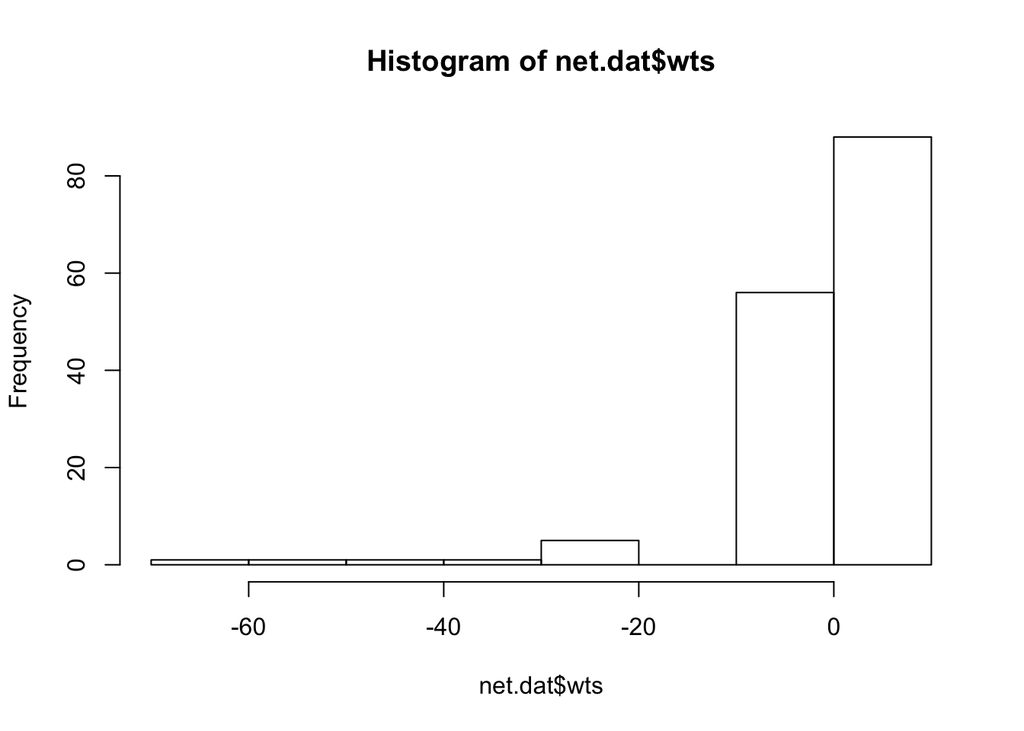

```r
  hist(net.dat$wts)
```